# Gene expression of L. plantarum WCFS1

Ivar van den Akker, Herke Schuffel, Yuri Wit en Peter Cserei

11/24/2020

## Inleiding

Doel: When L. plantarum is grown on a ribose-rich medium genes are upregulated that are required for metabolizing ribose.

## Materiaal en Methode

Dit R-script analyseert de expressie van genen van L. plantarum varianten: WCFS1 en NC8. Deze twee bacterien zijn gegroeid op verschillende bodems namelijk glucose (glc) en ribose (rib).

#### Library importeren

Importeren van library’s die nodig zijn voor het functioneren van onderstaande script.

```r
library(limma)
library(edgeR)
library(dplyr)
library(xlsx)
library(factoextra)
library(cluster)
library(latexpdf)
library(tinytex)
```

#### Bestand inladen

Het eerste variabel slaat de locatie van het bestand op. Vanzelfsprekend wordt ook de naam van het nodige bestand in een variabel opgeslagen.

De read.delim functie wordt over het algemeen gebruikt om tekstbestanden in te lezen waarbij data georganiseerd is in een data matrix layout. Binnen deze functie zijn de bovenste twee variabelen aan elkaar te plakken met paste0.

Daarbij wordt het kolom dat zorgt voor het oplopende nummering van rijen omgezet naar de ID kolom. Dit is gedaan om te voorkomen dat er verwarring ontstaat. De nummering van R zou namelijk niet overeen komen met de ID’s van de ingeladen data. Dit is van belang voor eventuele latere annotatie.

```r
fDir <- "./"
fName <- "RNA-Seq-counts.txt"
cnts <- read.delim(paste0(fDir,fName), comment.char="#")
row.names(cnts) <- cnts[,"ID"]

f2Name <- "WCFS1_anno.txt"
annotation <- read.delim(paste0(fDir,f2Name), comment.char = "#")
row.names(annotation) <- annotation[,row_number(0)]
```

#### DGE list maken

EdgeR slaat data op in een list-based data object genaamd een DGEList. Dit type object is gemakkelijk te gebruiken binnen R aangezien een DGEList gemanipuleerd kan worden zoals ieder ander lijst in R. Daarbij maakt een DGElist het mogelijk om berekeningen en statistiek toe te passen op de data. In het script worden de counts in de kolommen 2 t/m 9 gegroepeerd met de acht aangemaakte labels.

```r
label <- c("WCFS1.glc",  "WCFS1.glc",   "WCFS1.rib",    "WCFS1.rib",    "NC8.glc",  "NC8.glc",  "NC8.rib",  "NC8.rib")
group <- factor(label)
y <- DGEList(counts=cnts[,2:9],group=group)
```

#### Data normaliseren

Normalisatie wordt toegepast om biologische variatie uit de data te halen, zodat vervolgens de verschillende datasets met elkaar vergeleken kunnen worden. In R wordt dit gedaan door norm factors te berekenen. De TMM (trimmed mean of M-values) methode verwijdert eerst de laagste en hoogste waarden en bepaalt daarna het gemiddelde van de rest van de genen.

Hieronder zijn de norm factors weergegeven, zonder calcNormFactors toe te passen zou deze voor alle rijen 1 zijn. De data is genormaliseerd nadat het met de norm factors vermenigvuldigd is. Dit proces gaat automatisch in R na het veranderen van de norm factors.

```r
y <- calcNormFactors(y, method="TMM" )
print(y$samples)
```

```
##                 group lib.size norm.factors
## WCFS1.glc.1 WCFS1.glc 10153710    0.9850714
## WCFS1.glc.2 WCFS1.glc 10615392    0.9830048
## WCFS1.rib.1 WCFS1.rib  8959060    0.9986438
## WCFS1.rib.2 WCFS1.rib  9340139    1.0375329
## NC8.glc.1     NC8.glc  9821662    0.9390775
## NC8.glc.2     NC8.glc 10261922    1.0155475
## NC8.rib.1     NC8.rib  9951954    0.9899344
## NC8.rib.2     NC8.rib  9957519    1.0557378
```

#### Filteren op low counts

Deze functie zorgt ervoor dat genen geselecteert worden die niet significant genoeg zijn voor de dataset. Aangezien de dataset waarmee gewerkt wordt al een keer is gefilterd, resulteert de functie “filter by expression” maar in een hele kleine hoeveelheid genen, namelijk 20 stuks.

```r
keep <- filterByExpr(y)
y <- y[keep,]
```

### Cluster genes using hierarchal clustering

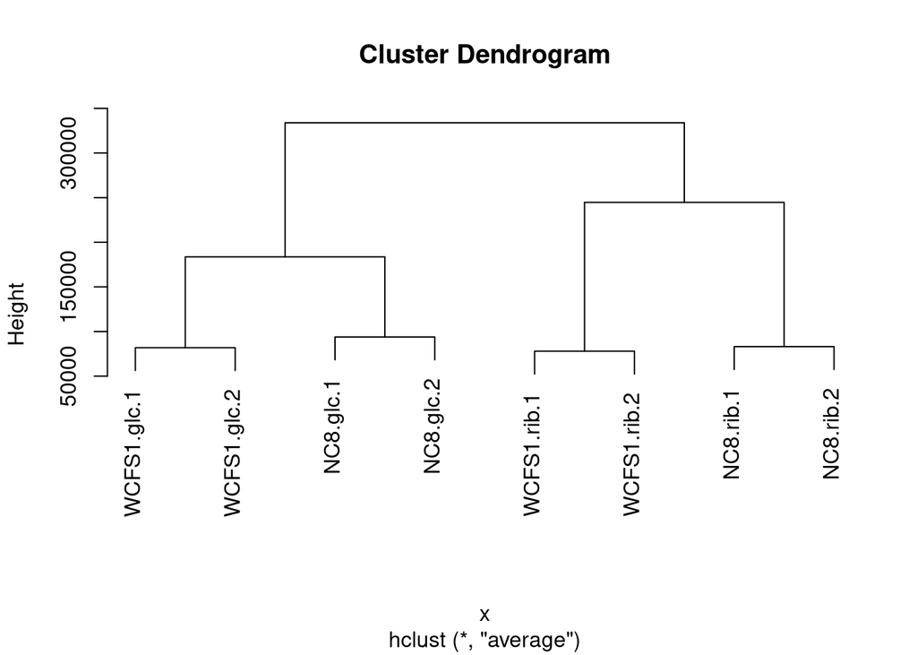

```r
x <- t(y$counts)
x <- dist(x, method = "euclidean")
x <- hclust(x, method = "average")
plot(x)
```